# Final Project

Maheshi Piumika AS2017457

10/5/2021

## Covid-19 Death Cases Highest Countries

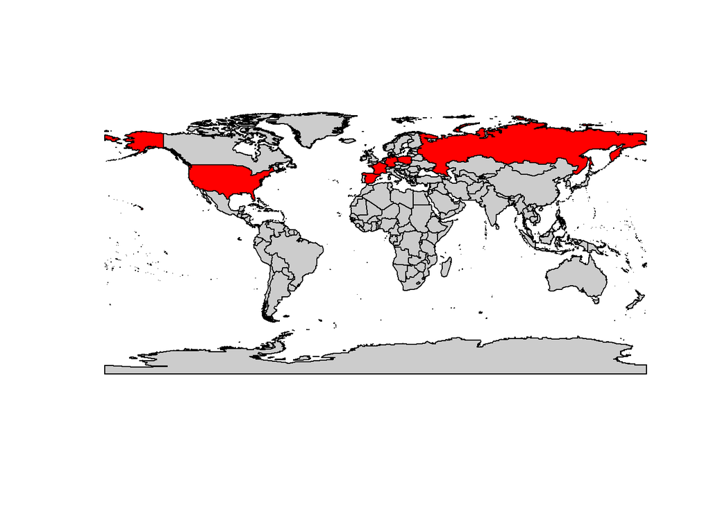

*Interpretation*

When consider about the death cases due to all the factors including Covid-19 the highest death counts are recorded from Russia, USA,Germany,France, Spain and Poland.

## Covid -19 Reported Cases in US by groups

[interactive chart not shown]

*Interpretation*

According to the races most of the infected peoples are from White and less from NH/PI. Black and Asian peoples are also affected as White peoples.

## Weekly Covid-19 Deaths among the Countries

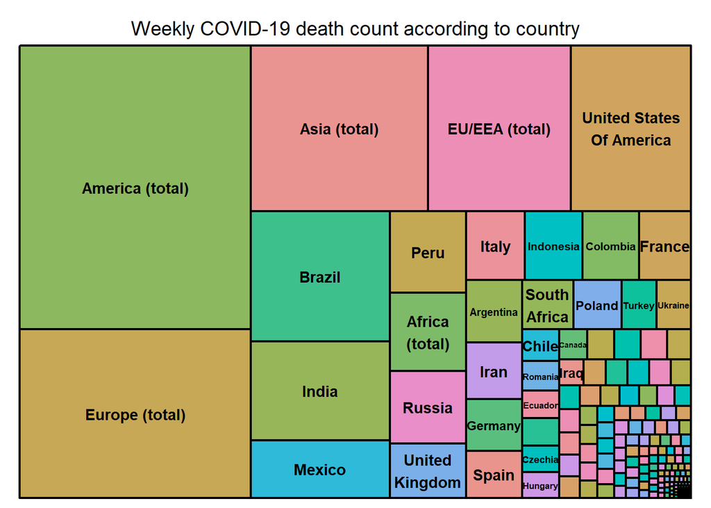

*Interpretation*

According to this graph we can identified highest weekly deaths counts due to Covid-19 are recorded from America and the next for the Europe continent. When considering the countries USA recorded the highest cases for weekly deaths due to Covid.Brazil and India recorded the highest weekly number of death cases after USA.

## US Covid Death Cases by Age and Sex

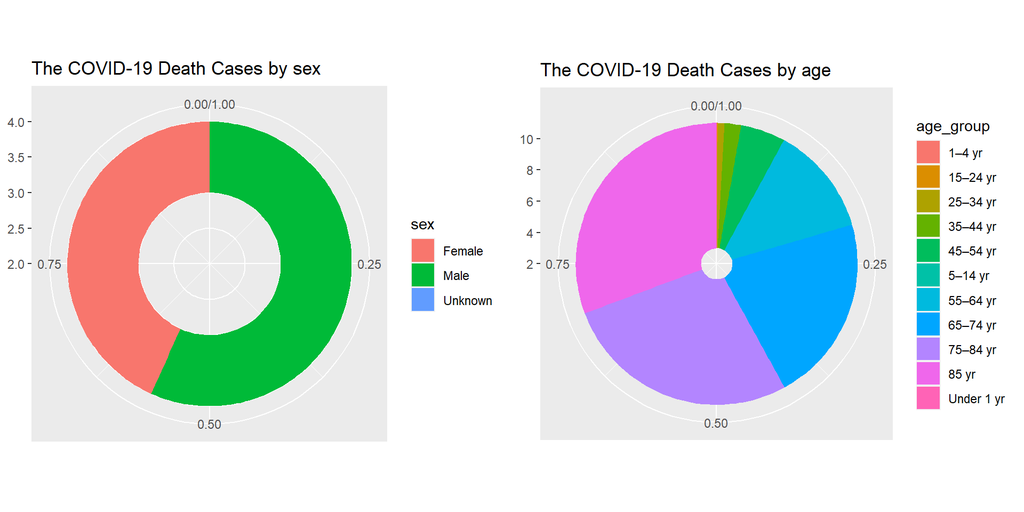

*Interpretation*